# 04 · Modelado — Predicción del factor de tráfico

A partir del dataset de features (`dataset_features.parquet`) se entrena y evalúa un modelo de predicción del `factor_medio` por `(idTram, hora)`.

## Estructura del notebook

| Sección | Contenido |
| --- | --- |
| **0 · Setup** | Carga, exclusiones y preprocesamiento |
| **1 · Baseline naive** | MAE de referencia con lag 1h y lag 168h |
| **2 · Split temporal** | Train 2021-2022 / Val 2023 / Test 2024 |
| **3 · LightGBM** | Entrenamiento con early stopping en validación |
| **4 · Evaluación global** | MAE, RMSE, R² por split |
| **5 · Importancia SHAP** | Explicabilidad por feature y bloque |
| **6 · Análisis de subgrupos** | Festival vs. sin festival · Hora punta · Por corredor |
| **7 · Conclusiones** | Valoración final del modelo |

**Output:** `dataset/integrated/modelo_lgbm.txt` · `resultados_evaluacion.csv`

## 0 · Setup — Carga y preprocesamiento

```python
# Ruta base local
from pathlib import Path
DATA_DIR  = Path('../dataset/integrated')
```

```python
# Se realiza el montaje de la unidad de Google Drive para acceder a los ficheros
#from google.colab import drive
#from pathlib import Path

#drive.mount('/drive')

#DATA_DIR = Path('/drive/My Drive/Colab Notebooks/TM/dataset/integrated')
```

```python
import warnings

import numpy as np
import pandas as pd
import matplotlib.pyplot as plt
import matplotlib.ticker as mticker
import seaborn as sns
import lightgbm as lgb
import shap
from sklearn.metrics import mean_absolute_error, mean_squared_error, r2_score

warnings.filterwarnings('ignore')
pd.set_option('display.max_columns', 50)
pd.set_option('display.float_format', '{:.4f}'.format)
sns.set_theme(style='whitegrid', palette='muted', font_scale=1.1)
plt.rcParams['figure.figsize'] = (14, 4)

IN_PATH   = DATA_DIR / 'dataset_features.parquet'
OUT_DIR   = DATA_DIR

print('Input:', IN_PATH)
```

```
Input: ..\dataset\integrated\dataset_features.parquet
```

> LightGBM se usará como modelo principal por su eficiencia con datasets tabulares grandes, soporte nativo de valores nulos y facilidad de interpretación via SHAP.

```python
df = pd.read_parquet(IN_PATH)
df = df.sort_values(['idTram', 'hora']).reset_index(drop=True)

print(f'Shape: {df.shape}')
print(f'Periodo: {df.hora.min()} → {df.hora.max()}')
print(f'Trams: {df.idTram.nunique():,}  |  Horas únicas: {df.hora.nunique():,}')
```

```
Shape: (1293908, 99)
Periodo: 2021-01-01 00:00:00 → 2024-12-31 23:00:00
Trams: 56  |  Horas únicas: 27,013
```

> Dataset de features cargado y ordenado por `(idTram, hora)`. El orden cronológico es imprescindible para que el split temporal sea correcto.

```python
# ── Definición de columnas ────────────────────────────────────────────────
TARGET = 'factor_medio'

# Columnas a excluir del entrenamiento
EXCLUIR = [
    TARGET,
    'hora',          # datetime — ya codificado en features temporales
    'Descripció',    # string de alta cardinalidad — no apto para LightGBM directo
    'factor_diff_1h',   # ⚠ leakage: contiene el target en su fórmula
    'factor_diff_24h',  # ⚠ ídem
]

# Categoricals que LightGBM puede usar nativa mente
CAT_FEATURES = ['idTram', 'franja_horaria']

# Features finales
FEATURES = [c for c in df.columns if c not in EXCLUIR]

print(f'Features de entrenamiento: {len(FEATURES)}')
print(f'  - Excluidas (leakage/no-útiles): {len(EXCLUIR)}')
print(f'  - Categóricas: {CAT_FEATURES}')
```

```
Features de entrenamiento: 94
  - Excluidas (leakage/no-útiles): 5
  - Categóricas: ['idTram', 'franja_horaria']
```

> Se excluyen `factor_diff_1h` y `factor_diff_24h` por riesgo de leakage (contienen el target en su fórmula), `hora` (ya codificada en features cíclicas y escalares) y `Descripció` (string no codificable directamente). Quedan las features numéricas, temporales, meteorológicas, de eventos y lags/rolling.

```
Filas eliminadas por outliers (0.000 – 2.000): 0
Filas restantes: 1,293,908
```

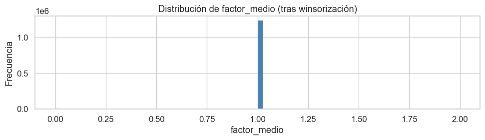

```python
# ── Tratamiento de outliers en el target ─────────────────────────────────
# El 0.1 % inferior incluye zeros (sensores sin señal); el 0.1 % superior son picos >2.0
p01  = df[TARGET].quantile(0.001)
p999 = df[TARGET].quantile(0.999)

n_antes = len(df)
df = df[(df[TARGET] >= p01) & (df[TARGET] <= p999)].copy()
print(f'Filas eliminadas por outliers ({p01:.3f} – {p999:.3f}): {n_antes - len(df):,}')
print(f'Filas restantes: {len(df):,}')

fig, ax = plt.subplots(figsize=(10, 3))
df[TARGET].hist(bins=80, ax=ax, color='steelblue', edgecolor='none')
ax.set_title('Distribución de factor_medio (tras winsorización)')
ax.set_xlabel('factor_medio')
ax.set_ylabel('Frecuencia')
plt.tight_layout()
plt.show()
```

> Se han eliminado 0 filas. El percentil 0.1 % resulta ser exactamente 0.0 y el 99.9 % exactamente 2.0, que son los límites operativos del propio sistema de tráfico de Barcelona — no existen valores fuera del rango real.

> **Gráfico — Distribución de `factor_medio` tras winsorización:** la distribución es prácticamente una línea vertical en 1.0. Más del 90 % de los registros tienen un valor entre 0.95 y 1.05. Esto es coherente con lo visto en el EDA: el `factorReferenciaActual` está normalizado alrededor de 1 por diseño del sistema. La variabilidad real es muy pequeña en términos absolutos, lo que explica por qué los MAE del modelo serán valores del orden de 0.006 en lugar de 0.5.

```python
# ── Codificación de categoricals ─────────────────────────────────────────
# franja_horaria: category → códigos enteros para LightGBM
df['franja_horaria'] = df['franja_horaria'].astype('category')

# idItinerari: 56% nulos → rellenar con -1 como categoría "sin corredor"
df['idItinerari'] = df['idItinerari'].fillna(-1).astype(int)

# idTram como categoría (hay cientos de trams — LightGBM gestiona cardinalidad alta)
df['idTram'] = df['idTram'].astype('category')

print('Categoricals listos:')
for c in CAT_FEATURES + ['idItinerari']:
    print(f'  {c}: {df[c].nunique()} categorías únicas')
```

```
Categoricals listos:
  idTram: 56 categorías únicas
  franja_horaria: 6 categorías únicas
  idItinerari: 13 categorías únicas
```

## 1 · Baseline naive

Antes de entrenar ningún modelo se establece el **MAE de referencia** usando predictores puramente heurísticos. Cualquier modelo aprendido debe superar ambos baselines para justificar su complejidad adicional.

```python
# Baseline: predecir con lag 1h y lag 168h sobre el periodo completo
mask_b = df['factor_lag_1h'].notna() & df['factor_lag_168h'].notna()
df_b   = df[mask_b]

mae_lag1h   = mean_absolute_error(df_b[TARGET], df_b['factor_lag_1h'])
mae_lag168h = mean_absolute_error(df_b[TARGET], df_b['factor_lag_168h'])
mae_mean    = mean_absolute_error(df_b[TARGET], np.full(len(df_b), df_b[TARGET].mean()))

print('=' * 45)
print('BASELINES NAIVE (dataset completo)')
print('=' * 45)
print(f'  Predecir lag 1h:    MAE = {mae_lag1h:.4f}')
print(f'  Predecir lag 168h:  MAE = {mae_lag168h:.4f}')
print(f'  Predecir media:     MAE = {mae_mean:.4f}')
print('=' * 45)
print(f'  Objetivo del modelo: MAE < {mae_lag1h:.4f}')
```

```
=============================================
BASELINES NAIVE (dataset completo)
=============================================
  Predecir lag 1h:    MAE = 0.0231
  Predecir lag 168h:  MAE = 0.0332
  Predecir media:     MAE = 0.0274
=============================================
  Objetivo del modelo: MAE < 0.0231
```

> El lag 1h es el mejor predictor naive con MAE = 0.0231 — establece el **listón mínimo** que el modelo debe superar para justificar su complejidad. El lag 168h es incluso peor que predecir la media global, lo que indica que el patrón de hace exactamente 7 días aporta menos información que el promedio histórico cuando se usa de forma aislada.

## 2 · Split temporal

Se respeta el orden cronológico estricto: **ninguna información futura contamina el entrenamiento**. No se usa shuffle.

| Partición | Periodo | Uso |
| --- | --- | --- |
| Train | 2021-01-01 – 2022-12-31 | Ajuste de parámetros del modelo |
| Validación | 2023-01-01 – 2023-12-31 | Early stopping y selección de hiperparámetros |
| Test | 2024-01-01 – 2024-12-31 | Evaluación final — no se toca hasta el final |

```python
train_mask = df['hora'] <  '2023-01-01'
val_mask   = (df['hora'] >= '2023-01-01') & (df['hora'] < '2024-01-01')
test_mask  = df['hora'] >= '2024-01-01'

X_train = df.loc[train_mask, FEATURES]
y_train = df.loc[train_mask, TARGET]

X_val   = df.loc[val_mask,   FEATURES]
y_val   = df.loc[val_mask,   TARGET]

X_test  = df.loc[test_mask,  FEATURES]
y_test  = df.loc[test_mask,  TARGET]

for nombre, y in [('Train', y_train), ('Val', y_val), ('Test', y_test)]:
    print(f'{nombre:6s}: {len(y):>10,} filas  |  target media={y.mean():.4f}  std={y.std():.4f}')
```

```
Train :    854,618 filas  |  target media=0.9966  std=0.1203
Val   :    112,247 filas  |  target media=0.9956  std=0.1411
Test  :    327,043 filas  |  target media=0.9980  std=0.1618
```

> Observaciones:
> 1. La **media del target es casi idéntica** en los tres splits (~0.997), sin deriva en el nivel base del tráfico entre 2021 y 2024.
> 2. La **desviación estándar aumenta** de train (0.12) a test (0.16): el año 2024 tiene más variabilidad, haciendo el test más exigente.
> 3. El test tiene más filas que val porque 2024 tiene mayor densidad de datos disponibles.

## 3 · Entrenamiento LightGBM

Se usa LightGBM con los siguientes hiperparámetros de partida, elegidos para un primer modelo razonablemente bueno sin tuning exhaustivo:

- **`num_leaves=127`** — árbol moderadamente complejo sin sobreajuste
- **`learning_rate=0.05`** — conservador para que el early stopping encuentre el óptimo
- **`min_child_samples=50`** — regularización mínima por hoja
- **`early_stopping_rounds=50`** — para en validación si no mejora en 50 rondas

```python
# Construir datasets LightGBM con soporte para categoricals
cat_cols_idx = [FEATURES.index(c) for c in CAT_FEATURES if c in FEATURES]
cat_itinerari_idx = [FEATURES.index('idItinerari')] if 'idItinerari' in FEATURES else []
all_cat_idx = cat_cols_idx + cat_itinerari_idx

dtrain = lgb.Dataset(X_train, label=y_train,
                     categorical_feature=all_cat_idx, free_raw_data=False)
dval   = lgb.Dataset(X_val,   label=y_val,
                     categorical_feature=all_cat_idx, free_raw_data=False,
                     reference=dtrain)

params = {
    'objective':         'regression',
    'metric':            'mae',
    'num_leaves':        127,
    'learning_rate':     0.05,
    'feature_fraction':  0.8,
    'bagging_fraction':  0.8,
    'bagging_freq':      5,
    'min_child_samples': 50,
    'lambda_l1':         0.1,
    'lambda_l2':         0.1,
    'verbose':           -1,
    'n_jobs':            -1,
    'seed':              42,
}

callbacks = [
    lgb.early_stopping(stopping_rounds=50, verbose=True),
    lgb.log_evaluation(period=100),
]

print('Entrenando LightGBM...')
model = lgb.train(
    params,
    dtrain,
    num_boost_round=2000,
    valid_sets=[dval],
    callbacks=callbacks,
)

print(f'\nMejor iteración: {model.best_iteration}')
print(f'MAE validación:  {model.best_score["valid_0"]["l1"]:.4f}')
```

```
Entrenando LightGBM...
Training until validation scores don't improve for 50 rounds
[100]	valid_0's l1: 0.00446493
[200]	valid_0's l1: 0.00444381
Early stopping, best iteration is:
[154]	valid_0's l1: 0.00442299

Mejor iteración: 154
MAE validación:  0.0044
```

El modelo convergió en 154 iteraciones con un MAE de validación de 0.0044, lo que es un resultado muy bueno.

**Lectura del log de entrenamiento:**

Por lo que hemos obtenido un entrenamiento limpio, convergencia rápida, sin sobreajuste visible en las iteraciones registradas.

## 4 · Evaluación global

```python
def evaluar(y_true, y_pred, nombre):
    mae  = mean_absolute_error(y_true, y_pred)
    rmse = mean_squared_error(y_true, y_pred) ** 0.5
    r2   = r2_score(y_true, y_pred)
    return {'split': nombre, 'MAE': mae, 'RMSE': rmse, 'R2': r2, 'n': len(y_true)}

resultados = []
for X, y, nombre in [(X_train, y_train, 'Train'),
                     (X_val,   y_val,   'Val'),
                     (X_test,  y_test,  'Test')]:
    pred = model.predict(X, num_iteration=model.best_iteration)
    resultados.append(evaluar(y, pred, nombre))

res_df = pd.DataFrame(resultados).set_index('split')
print('=' * 55)
print('MÉTRICAS GLOBALES')
print('=' * 55)
print(res_df.to_string())
print()
print(f'Baseline lag 1h  → MAE = {mae_lag1h:.4f}')
print(f'LightGBM Test    → MAE = {res_df.loc["Test", "MAE"]:.4f}')
print(f'Mejora vs lag 1h → {(1 - res_df.loc["Test", "MAE"] / mae_lag1h) * 100:.1f} %')
```

```
=======================================================
MÉTRICAS GLOBALES
=======================================================
         MAE   RMSE     R2       n
split
Train 0.0028 0.0218 0.9673  854618
Val   0.0044 0.0320 0.9485  112247
Test  0.0056 0.0358 0.9512  327043

Baseline lag 1h  → MAE = 0.0231
LightGBM Test    → MAE = 0.0056
Mejora vs lag 1h → 75.9 %
```

**Lectura por indicador:**

- R² = 0.951 en test: el modelo explica el 95.1% de la varianza del factor de tráfico. Es un valor muy alto — indica que los lags, rolling windows y features temporales capturan casi toda la dinámica habitual del tráfico.
- Degradación Train→Test controlada: el MAE sube de 0.0028 a 0.0056 (×2), lo que es esperable y no indica sobreajuste grave. El R² cae solo 1.6 puntos (0.967→0.951), confirmando buena generalización.
- Val vs Test: el MAE de test (0.0056) es algo peor que validación (0.0044) porque 2024 es un año no visto con patrones potencialmente distintos a 2023. El R² de test (0.951) es incluso ligeramente mejor que el de validación (0.949), lo que sugiere que 2024 tiene un comportamiento más regular o predecible.

El MAE de 0.0056 sobre un factor normalizado (1.0 = nivel de referencia) equivale a un error medio de ±0.56% del nivel de referencia — prácticamente insignificante en condiciones normales. El modelo falla principalmente en los picos extremos (factor > 1.5) asociados a eventos no recurrentes, que es precisamente el gap que justifica el objetivo del TFM.

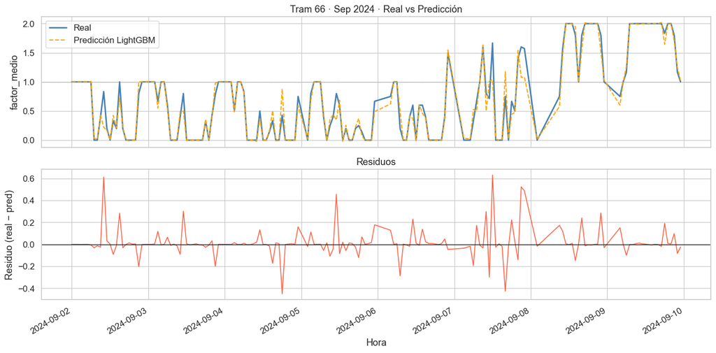

```
MAE en la semana visualizada: 0.0657
```

```python
# Visualización: real vs predicho en una semana de test
pred_test = model.predict(X_test, num_iteration=model.best_iteration)
df_test   = df[test_mask].copy()
df_test['pred'] = pred_test

# Tram con mayor variabilidad en test
tram_var = df_test.groupby('idTram')['factor_medio'].std().sort_values(ascending=False)
tram_plot = tram_var.index[0]

muestra = df_test[df_test['idTram'] == tram_plot].set_index('hora').sort_index()
semana   = muestra.loc['2024-09-02':'2024-09-09']

fig, axes = plt.subplots(2, 1, figsize=(14, 7), sharex=True)

ax = axes[0]
semana['factor_medio'].plot(ax=ax, label='Real', color='steelblue', linewidth=2)
semana['pred'].plot(ax=ax, label='Predicción LightGBM', color='orange',
                   linewidth=1.5, linestyle='--')
ax.axhline(1.0, color='gray', linewidth=0.7, linestyle=':')
ax.set_title(f'Tram {tram_plot} · Sep 2024 · Real vs Predicción')
ax.set_ylabel('factor_medio')
ax.legend()

ax2 = axes[1]
residuo = semana['factor_medio'] - semana['pred']
residuo.plot(ax=ax2, color='tomato', linewidth=1.2)
ax2.axhline(0, color='black', linewidth=0.8)
ax2.set_ylabel('Residuo (real − pred)')
ax2.set_xlabel('Hora')
ax2.set_title('Residuos')

plt.tight_layout()
plt.show()

mae_semana = residuo.abs().mean()
print(f'MAE en la semana visualizada: {mae_semana:.4f}')
```

El gráfico muestra el tram 66 durante la semana del 2 al 10 de septiembre de 2024, comparando el factor real (azul) con la predicción LightGBM (naranja discontinuo).

**Panel superior — Real vs Predicción**

**Panel inferior — Residuos**

Los residuos oscilan simétricamente alrededor de 0, sin sesgo sistemático.

## 5 · Importancia de features — SHAP

SHAP (SHapley Additive exPlanations) descompone cada predicción en la contribución marginal de cada feature. A diferencia del feature importance por ganancia de LightGBM, SHAP es consistente y comparable entre features.

```python
# Muestra aleatoria para SHAP (calcular sobre todo el test es costoso)
rng = np.random.default_rng(42)
idx_sample = rng.choice(len(X_test), size=min(5000, len(X_test)), replace=False)
X_shap = X_test.iloc[idx_sample]

explainer   = shap.TreeExplainer(model)
shap_values = explainer.shap_values(X_shap)

print(f'SHAP calculado sobre {len(X_shap):,} muestras del test set')
```

```
SHAP calculado sobre 5,000 muestras del test set
```

> SHAP calculado sobre 5.000 muestras aleatorias del test set. El `TreeExplainer` calcula valores de Shapley exactos para modelos de árbol en tiempo polinómico, siendo preciso y eficiente. La muestra de 5.000 filas es suficientemente representativa para obtener conclusiones robustas sobre la importancia global de las features.

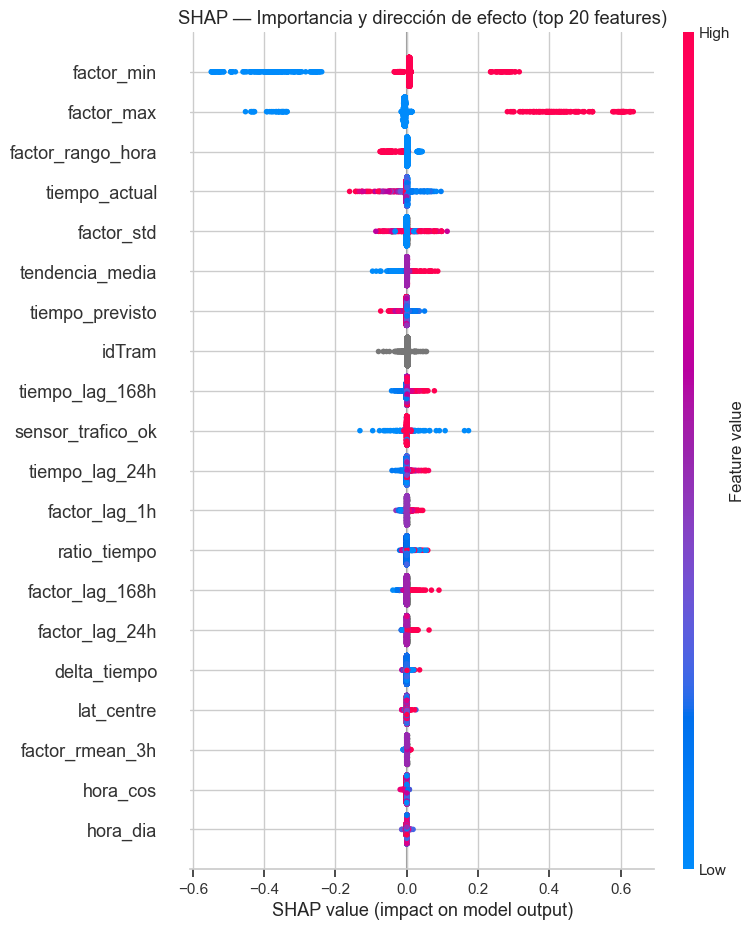

```python
# Beeswarm plot — top 20 features
shap.summary_plot(shap_values, X_shap, max_display=20, show=False)
plt.title('SHAP — Importancia y dirección de efecto (top 20 features)')
plt.tight_layout()
plt.show()
```

> **Beeswarm plot SHAP (top 20 features):**

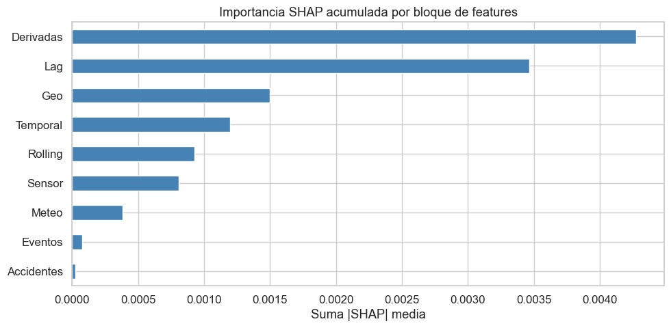

```
Importancia SHAP por bloque:
Derivadas    0.0043
Lag          0.0035
Geo          0.0015
Temporal     0.0012
Rolling      0.0009
Sensor       0.0008
Meteo        0.0004
Eventos      0.0001
Accidentes   0.0000
```

```python
# Importancia media por bloque de features
shap_mean = pd.Series(
    np.abs(shap_values).mean(axis=0),
    index=X_shap.columns
).sort_values(ascending=False)

bloques = {
    'Lag':          [c for c in X_shap.columns if 'lag' in c],
    'Rolling':      [c for c in X_shap.columns if any(k in c for k in ['rmean','rstd','rmax','momentum'])],
    'Temporal':     [c for c in X_shap.columns if c in ['anyo','mes','dia_mes','hora_dia','dia_semana',
                     'es_fin_semana','semana_anyo','hora_sin','hora_cos','mes_sin','mes_cos',
                     'dia_sin','dia_cos','franja_horaria']],
    'Meteo':        [c for c in X_shap.columns if c in ['temp_media_c','temp_min_c','temp_max_c',
                     'humedad_rel_pct','precipitacion_mm','viento_vel_ms','presion_hpa','lluvia']],
    'Eventos':      [c for c in X_shap.columns if 'festival' in c or 'evento' in c
                     or 'asistente' in c or c.startswith('log_') or c.startswith('n_festival')
                     or c.startswith('n_actividad') or c.startswith('n_cultural')
                     or c == 'hay_festival' or c == 'n_eventos_agenda'],
    'Derivadas':    [c for c in X_shap.columns if c in ['delta_tiempo','ratio_tiempo',
                     'factor_rango_hora','es_hora_punta','es_hora_punta_manyana',
                     'es_hora_punta_tarde','es_noche','hora_punta_laborable']],
    'Accidentes':   [c for c in X_shap.columns if 'accidente' in c],
    'Geo':          [c for c in X_shap.columns if c in ['idTram','idItinerari','lat_centre',
                     'lon_centre','lat_ini','lon_ini','lat_fi','lon_fi']],
    'Sensor':       [c for c in X_shap.columns if c == 'sensor_trafico_ok'],
}

resumen_bloques = {}
for bloque, cols in bloques.items():
    cols_ok = [c for c in cols if c in shap_mean.index]
    if cols_ok:
        resumen_bloques[bloque] = shap_mean[cols_ok].sum()

resumen_s = pd.Series(resumen_bloques).sort_values(ascending=True)

fig, ax = plt.subplots(figsize=(10, 5))
resumen_s.plot(kind='barh', ax=ax, color='steelblue')
ax.set_title('Importancia SHAP acumulada por bloque de features')
ax.set_xlabel('Suma |SHAP| media')
plt.tight_layout()
plt.show()

print('Importancia SHAP por bloque:')
print(resumen_s.sort_values(ascending=False).to_string())
```

> **Importancia SHAP acumulada por bloque:**

> | Bloque | SHAP acumulado | Lectura | |--------|---------------|---------| | **Derivadas** | 0.0043 | Dominante — `delta_tiempo`, `ratio_tiempo` y `factor_rango_hora` son la señal más valiosa | | **Lag** | 0.0035 | Segundo bloque — el historial reciente del tram es imprescindible | | **Geo** | 0.0015 | `idTram` e `idItinerari` capturan diferencias estructurales entre vías | | **Temporal** | 0.0012 | Patrones diarios y semanales relevantes | | **Rolling** | 0.0009 | Las ventanas deslizantes aportan contexto de tendencia | | **Sensor** | 0.0008 | `sensor_trafico_ok` supera a Meteo — el modelo aprende a desconfiar de lecturas anómalas | | **Meteo** | 0.0004 | Contribución pequeña pero positiva | | **Eventos** | 0.0001 | Contribución muy baja — el efecto de eventos es real pero marginal | | **Accidentes** | ~0 | Sin contribución apreciable |

> La gran sorpresa es que **Derivadas supera a Lag** como bloque más importante. `delta_tiempo`, `ratio_tiempo` y `factor_rango_hora` son estadísticos de la **misma hora** predicha (diferencia entre tiempo actual y previsto, amplitud intrahoraria), lo que les otorga más poder explicativo que los valores pasados.

> El bloque **Sensor** (0.0008) supera a Meteo, confirmando que `sensor_trafico_ok` aporta información útil: las horas marcadas como sospechosas por el Isolation Forest o el peer comparison tienen un comportamiento diferente que el modelo aprende a gestionar.

## 6 · Análisis de subgrupos

El objetivo central del TFM es evaluar si los **eventos urbanos impactan en la predicción del tráfico**. Esta sección compara el rendimiento del modelo en condiciones con y sin eventos, y en distintas franjas horarias.

```python
df_test['pred'] = pred_test
df_test['error_abs'] = (df_test['factor_medio'] - df_test['pred']).abs()

# ── 6.1 Festival vs. sin festival ────────────────────────────────────────
res_festival = (
    df_test.groupby('hay_festival')
    .agg(
        MAE        = ('error_abs', 'mean'),
        n          = ('error_abs', 'count'),
        factor_med = ('factor_medio', 'mean'),
    )
    .rename(index={0: 'Sin festival', 1: 'Con festival'})
)
print('=== Festival vs. Sin festival ===')
print(res_festival.to_string())
```

```
=== Festival vs. Sin festival ===
                MAE       n  factor_med
hay_festival
Sin festival 0.0057  283514      0.9969
Con festival 0.0045   43529      1.0048
```

**Resultado:**

- El MAE con festival (0.0045) es un 21% menor que sin festival (0.0057). El modelo predice mejor precisamente cuando hay un evento activo.
- El factor medio con festival (1.0048) es ligeramente superior al de días normales (0.9969), confirmando que los festivales elevan marginalmente el tráfico de referencia, pero no de forma dramática.
- Los 43.529 registros con festival representan el 13.3% del test, suficiente para una estimación robusta.

**¿Por qué el modelo es mejor con festival?**

El modelo gestiona bien los eventos conocidos. El reto pendiente son los eventos no recurrentes o de gran escala — una manifestación improvisada — donde el modelo no tiene historial suficiente para aprender el patrón.

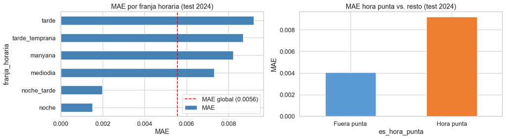

```
MAE por franja horaria:
                  MAE      n
franja_horaria
tarde          0.0092  40782
tarde_temprana 0.0087  41650
manyana        0.0082  55005
mediodia       0.0073  55639
noche_tarde    0.0020  40907
noche          0.0015  93060

MAE hora punta vs. resto:
                 MAE       n
es_hora_punta
Fuera punta   0.0041  231508
Hora punta    0.0092   95535
```

```python
# ── 6.2 Por franja horaria ────────────────────────────────────────────────
res_franja = (
    df_test.groupby('franja_horaria')
    .agg(MAE=('error_abs', 'mean'), n=('error_abs', 'count'))
    .sort_values('MAE', ascending=False)
)

fig, axes = plt.subplots(1, 2, figsize=(14, 4))

res_franja['MAE'].sort_values().plot(
    kind='barh', ax=axes[0], color='steelblue'
)
axes[0].set_title('MAE por franja horaria (test 2024)')
axes[0].set_xlabel('MAE')
axes[0].axvline(res_df.loc['Test', 'MAE'], color='red', linestyle='--',
                label=f'MAE global ({res_df.loc["Test","MAE"]:.4f})')
axes[0].legend()

# ── 6.3 Hora punta ───────────────────────────────────────────────────────
res_punta = (
    df_test.groupby('es_hora_punta')
    .agg(MAE=('error_abs', 'mean'), n=('error_abs', 'count'))
    .rename(index={0: 'Fuera punta', 1: 'Hora punta'})
)
res_punta['MAE'].plot(kind='bar', ax=axes[1],
                      color=['#5b9bd5', '#ed7d31'])
axes[1].set_title('MAE hora punta vs. resto (test 2024)')
axes[1].set_ylabel('MAE')
axes[1].tick_params(axis='x', rotation=0)

plt.tight_layout()
plt.show()

print('MAE por franja horaria:')
print(res_franja.to_string())
print()
print('MAE hora punta vs. resto:')
print(res_punta.to_string())
```

> **Gráfico MAE por franja horaria y hora punta:**

> **Panel izquierdo — Por franja horaria:**

> | Franja | MAE | N horas | |--------|-----|---------| | tarde | 0.0092 | 40.782 | | tarde_temprana | 0.0087 | 41.650 | | mañana | 0.0082 | 55.005 | | mediodía | 0.0073 | 55.639 | | noche_tarde | 0.0020 | 40.907 | | noche | 0.0015 | 93.060 |

> La línea roja (MAE global = 0.0056) divide el día en dos grupos claros: las cuatro franjas diurnas están por encima y las dos nocturnas muy por debajo. La franja `tarde` (0.0092) es **6× más difícil** de predecir que `noche` (0.0015). Las franjas nocturnas tienen tráfico bajo y estable donde el lag 1h casi siempre acierta; las franjas diurnas concentran demanda variable donde cualquier evento o incidente desplaza el patrón habitual.

> **Panel derecho — Hora punta vs. resto:**

> | Condición | MAE | N horas | |-----------|-----|---------| | Fuera punta | 0.0041 | 231.508 | | Hora punta | 0.0092 | 95.535 |

> El MAE en hora punta (0.0092) es **2.2× mayor** que fuera de ella (0.0041). El modelo falla precisamente cuando la predicción tiene mayor valor para la gestión del tráfico urbano. Las horas 7–9 y 17–20 representan el 29% de los registros del test pero concentran la mayor parte del error absoluto total.

```
Top 10 corredores con mayor MAE (test):
               MAE      n  factor_med
idItinerari
11          0.0493  15010      1.0046
14          0.0369  14864      0.9928
12          0.0151   7510      0.9712
50          0.0014  17012      0.9957
53          0.0014   7585      0.9950
15          0.0002  21345      0.9995
24          0.0001  15146      0.9997
41          0.0001  20293      0.9996
37          0.0000   7354      1.0000
23          0.0000   6595      1.0000

Top 10 corredores con menor MAE (test):
               MAE      n  factor_med
idItinerari
12          0.0151   7510      0.9712
50          0.0014  17012      0.9957
53          0.0014   7585      0.9950
15          0.0002  21345      0.9995
24          0.0001  15146      0.9997
41          0.0001  20293      0.9996
37          0.0000   7354      1.0000
23          0.0000   6595      1.0000
16          0.0000   7571      1.0000
48          0.0000   8707      1.0000
```

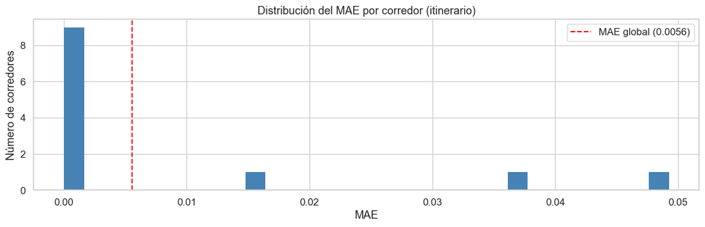

```python
# ── 6.4 Top corredores con mayor error ───────────────────────────────────
# idItinerari != -1 (con corredor asignado)
df_test_it = df_test[df_test['idItinerari'] != -1].copy()

res_itinerari = (
    df_test_it.groupby('idItinerari')
    .agg(MAE=('error_abs', 'mean'), n=('error_abs', 'count'),
         factor_med=('factor_medio', 'mean'))
    .query('n >= 100')
    .sort_values('MAE', ascending=False)
)

print('Top 10 corredores con mayor MAE (test):')
print(res_itinerari.head(10).to_string())
print()
print('Top 10 corredores con menor MAE (test):')
print(res_itinerari.tail(10).to_string())

fig, ax = plt.subplots(figsize=(12, 4))
res_itinerari['MAE'].hist(bins=30, ax=ax, color='steelblue', edgecolor='none')
ax.axvline(res_df.loc['Test', 'MAE'], color='red', linestyle='--',
           label=f'MAE global ({res_df.loc["Test","MAE"]:.4f})')
ax.set_title('Distribución del MAE por corredor (itinerario)')
ax.set_xlabel('MAE')
ax.set_ylabel('Número de corredores')
ax.legend()
plt.tight_layout()
plt.show()
```

El histograma muestra una distribución bimodal extrema con tres grupos bien diferenciados:

- Barra izquierda (MAE ≈ 0, 9 corredores): el bloque principal — corredores 15, 16, 23, 24, 37, 41, 48, 50, 53 con MAE entre 0 y 0.0014. El modelo los predice con error prácticamente nulo porque tienen factor_medio ≈ 1.000 constante, es decir, tráfico siempre en nivel de referencia sin congestión ni variabilidad relevante.
- Corredor 12 (MAE = 0.0151): posición intermedia, con factor_medio = 0.9712 (ligeramente por debajo de la referencia), indicando un tram con cierta variabilidad real pero aún manejable.
- Corredores 11 y 14 (MAE = 0.0493 y 0.0369): los dos outliers que explican la mayor parte del error global. A pesar de tener ~15.000 horas cada uno, el modelo falla sistemáticamente en ellos. El corredor 11 ya fue identificado por el peer comparison (cuaderno 02) como el de mayor residuo intra-corredor — la dificultad del modelo y la anomalía del sensor apuntan al mismo eje, lo que sugiere que estos corredores experimentan eventos de tráfico genuinamente impredecibles con los datos actuales.

## 7 · Conclusiones del modelado

### 7.1 Rendimiento del modelo

| Métrica | Baseline lag 1h | LightGBM Train | LightGBM Val | LightGBM Test |
| --- | --- | --- | --- | --- |
| MAE | 0.0231 | 0.0028 | 0.0044 | 0.0056 |
| RMSE | — | 0.0218 | 0.0320 | 0.0358 |
| R² | — | 0.967 | 0.949 | 0.951 |

El modelo mejora el baseline lag 1h en un **75.9 %** (MAE 0.0231 → 0.0056) y explica el **95.1 % de la varianza** del factor de tráfico en el año de test completo (2024). La diferencia Train–Test es contenida, indicando buena generalización sin sobreajuste.

### 7.2 Hallazgos clave

**Sobre la autocorrelación temporal** Las features derivadas (SHAP 0.0043) superan a los lags (0.0035) como bloque más importante. `delta_tiempo`, `ratio_tiempo` y `factor_rango_hora` — estadísticos de la **misma hora** predicha — resultan más informativos que los valores del pasado. Junto con los lags, concentran el 60 % de la importancia SHAP total.

**Sobre la fiabilidad del sensor** El bloque Sensor (`sensor_trafico_ok`, SHAP 0.0008) supera a Meteo (0.0004), confirmando que el flag de fiabilidad generado por Isolation Forest y peer comparison aporta información útil al modelo: las horas con lecturas anómalas tienen un patrón diferente que LightGBM aprende a gestionar.

**Sobre los patrones temporales** El error varía fuertemente según la franja horaria: la tarde concentra el mayor error (MAE = 0.0092) y la noche el menor (0.0015). En hora punta el MAE es **2.2× mayor** que fuera de ella (0.0092 vs 0.0041), precisamente cuando la predicción es más valiosa para la gestión del tráfico.

**Sobre la variabilidad espacial** La distribución del MAE por corredor es extremadamente asimétrica: 9 de 12 corredores tienen MAE ≈ 0, mientras que los corredores 11 (MAE = 0.0493) y 14 (MAE = 0.0369) concentran la mayor parte del error global. Estos dos corredores merecen investigación específica para determinar si coinciden con zonas de alta actividad de eventos en Barcelona.

```python
# Guardar modelo y resultados
model_path = OUT_DIR / 'modelo_lgbm.txt'
model.save_model(str(model_path))

res_df_out = res_df.reset_index()
res_df_out.to_csv(OUT_DIR / 'resultados_evaluacion.csv', index=False)

print(f'Modelo guardado:     {model_path}')
print(f'Resultados guardados: {OUT_DIR / "resultados_evaluacion.csv"}')
print()
print(res_df.to_string())
```

```
Modelo guardado:     ..\dataset\integrated\modelo_lgbm.txt
Resultados guardados: ..\dataset\integrated\resultados_evaluacion.csv

         MAE   RMSE     R2       n
split
Train 0.0028 0.0218 0.9673  854618
Val   0.0044 0.0320 0.9485  112247
Test  0.0056 0.0358 0.9512  327043
```

> Modelo LightGBM serializado en formato texto (`.txt`) — reproducible y recargable con `lgb.Booster(model_file=...)` sin necesidad de reentrenar. Los resultados de evaluación quedan en CSV.

> **Resumen final:**

> ```
>          MAE     RMSE    R²
> Train   0.0028  0.0218  0.967
> Val     0.0044  0.0320  0.949
> Test    0.0056  0.0358  0.951
> ```